# INTRODUCTION TO PLS 206

Emilio A. Laca

1 October 2014

## What are multivariate statistics?

Operationally, we can define multivariate systems as systems whose state and behavior needs more than one variable to be fully described. Clearly, most systems are multivariate. But in research and modeling we sometimes reduce systems to a single variable for practical purposes. We could discuss the concept that the Dow Jones index is a univariate system because all you can and need to know about it is its current state, a single number.

Although the word “*multivariate*” refers to the fact that multiple variables are involved,, there are two types of definitions of multivariate statistics.

- First, in the most general sense, multivariate or multivariable analysis is the branch of statistics that deals simultaneously with more than two variables.
- In a more strict sense, multivariate analysis deals with multiple *response* (or dependent) variables simultaneously.

Therefore, multiple linear regression is a multivariate method according to the first definition, but it is not a “true” multivariate method according to the strict definition. There is a statistical method or approach called *multivariate multiple linear regression* that is a true multivariate method. MANOVA is a true multivariate method because it handles multiple response variables.

## Statistic

A statistic is the result of applying a function or algorithm to a set of data. For example, the average of a sample is a statistic, where the algorithm consists of adding all values in teh sample and dividing the result by the sample size. Other typical statistics are the median of a sample, the sample variance, the maximum and minimum, etc.

> Statistics are random variables.

> Statistics are different from parameters.

> Parameters are fixed quantities that are typically unobservable.

## Dependent and independent variables.

In statistics in general we consider sets of variables called independent, explanatory, or X variables (IV’s), and sets of variables labeled as dependent or Y variables (DV’s). Typically, variables are not intrinsically dependent or independent. The classification depends on the details of the study, including the purpose of the analysis and the way in which the data were obtained.

Consider for example the study of the relationship between animals size and food consumption. If the goal of the study is to determine whether larger animals of a population tend to eat more, we take a stratified random sample of the population in case (say the deer of Stanislaus National Forest, SNF), where each stratum has animals of closely similar weight, and expose all of them to equal food availability. Then, food consumption is measured and the relationship between food consumption (Y) and animal size (X) is studied. If the goal of the study is to determine whether animals that consume more food tend to be larger we could measure the amount of food consumed in “natural” conditions by a random sample of deer, stratify by level of food consumption, and measure deer size. Then, size (Y) can be related to food consumption (X). Notice that in neither case was “effect of X on Y” mentioned. We just said deer with greater X tend to have greater (smaller) Y. This relates to the concept of cause and effect considered below.

Before going on to the next section, you may want to think about the example above where I said that deer of different sizes are exposed to equal food availability. Is that a necessary condition or does it also depend on the goals of the study? Think about what you would be able to say about the expected food consumption of deer of different sizes at SNF.

## Models

Most if not all statistical methods and techniques use models. In a deep sense, data can make sense in relation to some model of reality. This concept is summarized in the following:

> Data = Model + Error = Signal + Noise = f(predictors, parameters) + random variable

Further, other models that we will consider in this course have different types of errors or random components. For example, models where residuals are correlated because of proximity in space or time can be written as:

> Data = Deterministic model + Random structure model + unstructured error

Notice that each data value is partitioned into the components listed. The same data can be partitioned in different ways depending on the goals of the analysis. This is seen, for example, when the same data set is analyzed as a mixed model, where part of the model includes a random component with structure (the random effects), or as a generalized model, where all random components are incorporated into a “noise” that itself has structure. By “structure”, we mean that the random components have certain covariance patterns, as opposed to IID errors.

> IID means independent identically distributed

## True multivariate statistics

Some authors define true multivariate statistics are those methods that deal with multiple Y or response variables, regardless of the number of X’s. Others consider that just having multiple X’s qualifies as multivariate, but typically exclude any kind of ANOVA that has only one Y or response variable. For example, an experiment with two factors (say N and P fertilization) where yield is the only response variable, is considered univariate.

Most people agree that MANOVA, discriminant analysis (DA), principal components analysis (PCA), canonical correlation (CCA), etc. are multivariate. It should be mentioned that pure PCA only contains X’s; no Y’s are involved. Multiple linear regression and path analysis are sort of in the gray area. There is a true multivariate version of MLR, where many Y’s are regressed on many X’s, and everyone agrees this is a multivariate case.

Usually, scientists treat truly multivariate situations in a univariate fashion. For example, when an experiment is performed to study the effect of NxP fertilization on a crop, usually one measures not only yield but a number of other Y’s. Yet, we typically analyze each Y separately. The implications of this may range from giving incorrect probability levels to having little impact. Univariate analysis may lead to true error rates being greater than the nominal $\alpha$ level, a situation called “inflated error rates.” A multivariate approach is more conservative and may have more true power (1-$\beta$). Moreover, some results are only detectable, understandable, or “visible” with a multivariate approach. Let’s take a look at an example.

## Univariate and multivariate differences

The step from univariate to true multivariate statistics involves one crucial increase in complexity, the use of multivariate distributions. In addition, it requires that we reconsider the way in which we compare populations or objects. In univariate statistics this is not an issue, because objects, samples and populations are compared on a single characteristics at a time. For example, two soils can be compared based on their organic matter content (OM); two plant communities can be compared based on the abundance of a single species. Soils with similar organic matter content are considered more similar to each other than soils with widely different organic matter contents. When we consider more than one variable, say OM and pH things change. Consider the following two pairs of soils. Which pair is more different than the other? Table 1‑1. When two or more variables are used to compare objects, the concept of degree of difference becomes more complex. It is necessary to introduce the concept of distance, and statistical distance.

| Variable | 1st pair |  | 2nd Pair |  |
| --- | --- | --- | --- | --- |
| _________ | Soil A | Soil B | Soil X | Soil Y |
| OM% | 3.0 | 4.0 | 3.0 | 5.0 |
| pH | 7.0 | 6.0 | 6.5 | 6.5 |

One possible solution is to measure or calculate the **Euclidean distance** between the objects, but this approach ignores the inherent errors and variances of the population. Multivariate analysis uses the statistical distance as a measure of differences in multiple dimensions. One of the consequences of the concept of multivariate differences is that populations can simultaneously be not significantly different in any single characteristic, and be significantly different in a multivariate sense. The concepts of distance, statistical distance, and multivariate differences will be expanded in future chapters.

```r
soils <- data.frame(soil = c("A", "B", "X", "Y"), OM = c(3.0, 4.0, 3.0, 5.0), pH = c(7.0, 6.0, 6.5, 6.5))
soils
```

```
##   soil OM  pH
## 1    A  3 7.0
## 2    B  4 6.0
## 3    X  3 6.5
## 4    Y  5 6.5
```

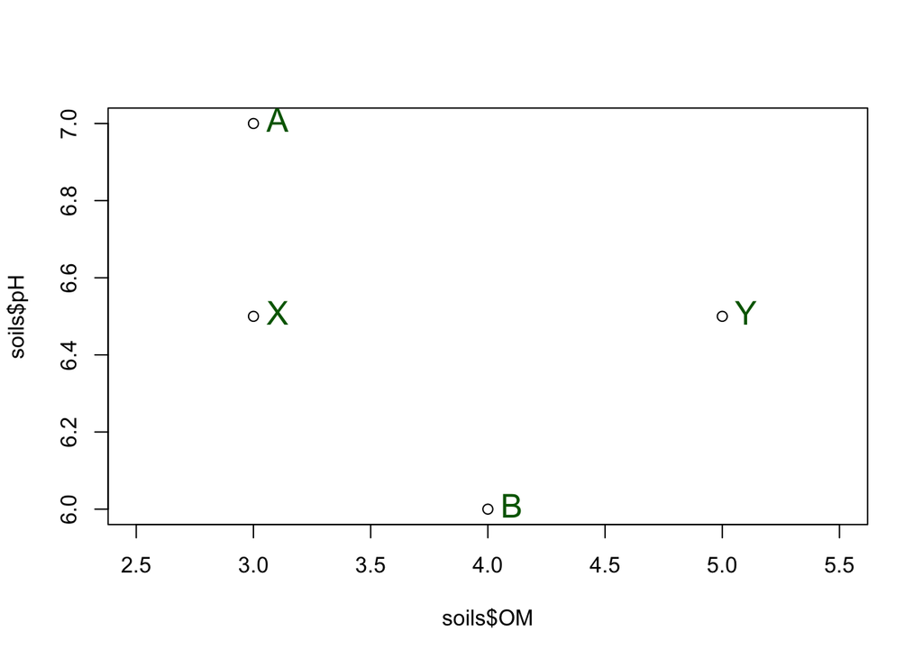

```r
plot(soils$OM, soils$pH, xlim = c(2.5, 5.5))
text(soils$OM, soils$pH, soils$soil, cex=1.5, pos=4, col="darkgreen")
```

```r
dist(soils[,2:3], method = "euclidean")
```

```
##       1     2     3
## 2 1.414
## 3 0.500 1.118
## 4 2.062 1.118 2.000
```